# Imputando Contexto Social a las encuestas

- Mostrar todo el código
- Ocultar todo el código
- Ver el código fuente

Autor/a

Aníbal Olivera

Fecha de publicación

8 de enero de 2025

## 1. Introducción

En la práctica es importante considerar los entornos sociales: conversaciones cotidianas, exposición repetida a puntos de vista, normas locales, etc. En otras palabras, *dos individuos con demografías similares pueden diferir en sus actitudes si viven en “mundos sociales” distintos*.

### 1.1 Los peligros de interpretar regresiones tradicionales

**¿**Qué pasa si los datos observados en una encuesta son el resultado de procesos de *difusión* en redes con homofilia **?**

En el paper de DellaPosta et al. (2015) *Why Do Liberals Drink Lattes?* [https://doi.org/10.1086/681254] muestran que incluso **sin ningún efecto causal** directo de una variable sociodemográfica (ej. educación, ideología) sobre una conducta o preferencia (ej. consumo cultural), una regresión estándar puede producir coeficientes grandes y significativos, simplemente porque:

- las personas interactúan principalmente con otros similares (homofilia), y
- las conductas/actitudes se difunden a través de esas interacciones.

Supongamos que estimas el siguiente modelo:
$$y_i=\beta_0+\beta_1 \text { Educación }_i+\varepsilon_i$$

donde $y_i$ es la actitud política, gusto cultural, consumo, etc. La interpretación puede ser que si $\hat{\beta}_1>0$, se concluye que “la educación influye en la actitud $y_i$.”

Ahora, DellaPosta et al. (2015) simulan un mundo donde:

1. No hay efecto causal directo:
   $$\text { Educación }_i \nrightarrow y_i$$
2. La educación solo afecta con quién interactúas:
- Alta educación → interactúas con gente similar.
- Baja educación → lo mismo.
3. Las actitudes se actualizan por influencia social:
   $$y_i(t+1)=f\left(y_j(t): j \in N(i)\right)$$
4. Como las redes son homofílicas:
- Los altamente educados terminan compartiendo actitudes entre sí.
- Lo mismo ocurre en otros grupos.

**¿**Qué observa el investigador **?**

No ve la red ni la dinámica, solo una foto final:

- Personas con alta educación $\rightarrow$ valores similares de $y$.
- Personas con baja educación $\rightarrow$ valores distintos.

Y cuando corre la regresión obtiene $\hat{\beta}_1$ grande, y significativo.

Pero el supuesto implícito *las observaciones son independientes condicionalmente a las covariables* es falso porque $y_i$ depende de $y_j$: la regresión confunde un efecto individual, con un **proceso relacional y contextual**.

### Pasos para imputar contexto social

Este módulo busca imputar contexto social en encuestas que no midieron redes personales. Para ello, se utiliza la metodología presentada en:

McPherson, M., & Smith, J. A. (2019). Network Effects in Blau Space: Imputing Social Context from Survey Data. *Socius*, 5. [10.1177/2378023119868591].

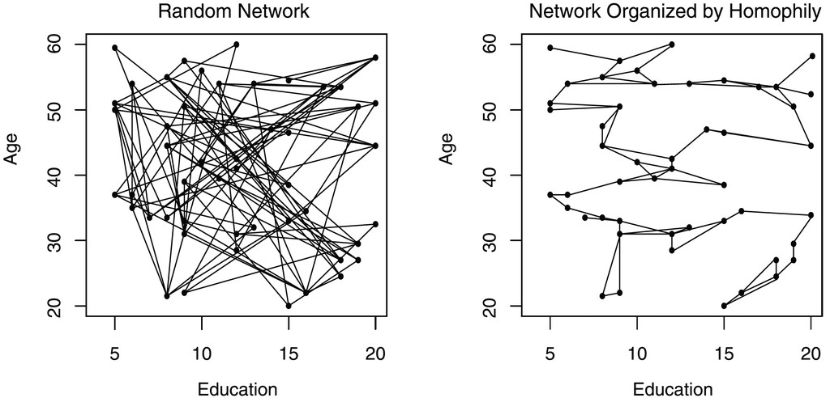

Figure 1. Example networks in two-dimensional Blau space.

1. Estimar fuerza homofílica en una encuesta #1 que es *representativa de una población* con datos Ego-network: Al estimar
   $$\operatorname{logit}\left(\operatorname{Pr}\left(Y_{i j}=1\right)\right)=\alpha+\boldsymbol{\beta}^{\top} \mathbf{d}_{i j}+\boldsymbol{\gamma}^{\top}\left(\mathbf{d}_{i j} \cdot \mathbb{I}_{2004}\right)$$

   obtenemos los coeficientes $\hat{\boldsymbol{\beta}}, \hat{\boldsymbol{\gamma}}$, interpretados como “fuerza homofílica” por dimensión. (Nosotros usaremos $\hat{\boldsymbol{\beta}_{\text{tot}}}=\hat{\boldsymbol{\beta}}+\hat{\boldsymbol{\gamma}}$).
2. Tomamos los coeficientes estimados en el paso 1 y los aplicamos a una encuesta focal #2 que es:
   - **distinta** de la encuesta de datos ego-network,
   - presenta un outcome $y_i$ de interés,
   - que tiene las mismas covariables $X_i$ (edad, educación, raza, religión, género, etc.) y
   - que es representativa de la **misma población**.

   Después de obtener los coeficientes, calculamos la probabilidad de interacción $W_{ij}$ entre $i$ y $j$, basada en sus distancias sociales, así como los coeficientes del paso 1.
3. Construimos el contexto social a ser imputado:
   $$(W y)_i=\sum_{j=1}^{n} W_{ij}\,y_j.$$
   El término $(W y)_i$ es el promedio ponderado de $y$ en los “alters imputados” de $i$, ponderado por propensión homofílica a interactuar (cercanía en Blau space).
4. Estimamos un modelo de autocorrelación espacial sobre la encuesta focal:
   $$y = \rho (W y) + X \beta + \epsilon, \quad \epsilon \sim M V N\left(0, \sigma^2 I\right).$$
   donde $\rho$ captura asociación entre outcome individual y el “clima” del entorno social imputado producido por $W$.

### 1.2. Término Contextual

Los coeficientes $\boldsymbol{\beta}$ (calculados usando *case-control design*) cuantifican cómo cambia la propensión al lazo al aumentar la distancia sociodemográfica:

$$\text{logit}\big(\Pr(Y_{ij}=1)\big) = \alpha + \boldsymbol{\beta}^\top \mathbf{d}_{ij}.$$

Dado que el intercepto $\alpha$ no es interpretable como densidad real bajo *case-control*, trabajamos con **probabilidades relativas** de lazo, definiendo un peso:

$$w_{ij} \propto \exp\!\left(\boldsymbol{\beta}^\top \mathbf{d}_{ij}\right), \quad (\text{con } w_{ii} = 0),$$

que inducen una distribución sobre potenciales alters $j$ que favorece pares cercanos en Blau space. A partir de esta estructura construimos una matriz de pesos $W$ que representa “vecindad social” imputada (no geográfica),
$$W_{ij} = \frac{w_{ij} \cdot \mathbb{I}(j \in \mathcal{N}_i)}{\sum_{k \in \mathcal{N}_i} w_{ik}}.$$

donde $\mathcal{N}_i \;=\; \{\, j \neq i \;:\; j \text{ está entre los } K \text{ mayores } w_{ij} \,\}$ es un término para seleccionar solo los vecinos más probables. Los valores en la matriz $W$ reflejan los tipos de personas que $i$ es probablemente conocer, dados las distancias sociales entre $i$ y las demás personas en la población. Finalmente, calculamos el término contextual:

$$(Wy)_i = \sum_{j \neq i} W_{ij}\, y_j,$$

donde $y_j$ es la variable de interés del individuo $j$. Intuitivamente, $(Wy)_i$ es una medida de “clima actitudinal” alrededor de $i$.

## 2. Imputando Contexto Social (ANES 2016, Democrat Scale)

Para replicar el ejercicio empírico, utilizamos ANES 2016 (pre-election survey), que **no** tiene EGO-net. Imputaremos contexto social y evaluarémos si mejora la explicación de *Democrat Scale* (grado de simpatía/afinidad hacia el Partido Demócrata, reportado por McPherson & Smith) más allá de la demografía. Estimaremos dos modelos:

**Modelo 1:** (demografía)
$$y = X \beta + \epsilon, \quad \epsilon \sim \mathcal{N}(0, \sigma^2),$$
donde $\mathbf{x}_i$ incluye edad, educación, género, dummies de raza/etnicidad y religión.

**Modelo 2:** (demografía + contexto social imputado)
$$y = \rho (W y) + X \beta + \epsilon, \quad \epsilon \sim M V N\left(0, \sigma^2 I\right).$$
donde $\rho$ captura la asociación entre el outcome individual y el clima actitudinal del entorno social imputado.

El foco interpretativo será (i) si $\rho>0$ y es estadísticamente distinguible de cero, y (ii) si la inclusión de $(Wy)_i$ reduce la magnitud de varios coeficientes demográficos, coherente con la lectura “contextual” discutida para Democrat Scale.

### 2.1. Construcción de Pesos (W)

Cargamos datos limpios de la ANES 2016 (preparados en `anes-cleaning.qmd`).

**Código**

```r
library(dplyr)
library(tidyr)
library(spdep)
library(spatialreg)
library(texreg)

# Cargar datos limpios
final_df <- readRDS("data/anes_2016_derived/anes_clean.rds")
cat("Datos ANES cargados. N =", nrow(final_df), "\n")
```

```
Datos ANES cargados. N = 4045
```

Construimos una matriz de pesos espaciales $W$ basada en la similitud demográfica. Para eficiencia computacional, utilizamos una aproximación *k-nearest* (k=100) en probabilidad.

**Código**

```r
# Demográficos
vars_model <- c(
    "y", "age", "educ", "female", "race_raw", "relig_raw",
    "race_black", "race_hispanic", "race_asian", "race_native", "race_other",
    "relig_catholic", "relig_jewish", "relig_none", "relig_other"
)

final_df <- final_df %>%
    select(all_of(vars_model)) %>%
    drop_na()

X_age <- final_df$age
X_educ <- final_df$educ
X_sex <- final_df$female
X_race <- as.integer(final_df$race_raw)
X_relig <- as.integer(final_df$relig_raw)

# Calculamos distancias
D_age <- abs(outer(X_age, X_age, "-"))
D_educ <- abs(outer(X_educ, X_educ, "-"))
D_sex <- abs(outer(X_sex, X_sex, "-"))
D_race <- outer(X_race, X_race, function(x, y) ifelse(x != y, 1, 0))
D_relig <- outer(X_relig, X_relig, function(x, y) ifelse(x != y, 1, 0))

# Betas de Homofilia (Basados en Replicación V3 - GSS 2004)
# Estos valores corresponden a (beta + delta_2004) del modelo recreado
betas <- c(
    race = -1.352, relig = -1.354, sex = -0.256, age = -0.047, educ = -0.189
)

cat("Calculando distancias en Blau Space...\n")
```

```
Calculando distancias en Blau Space...
```

**Código**

```r
# 1. Calcular Distancias (Blau Space)
D_age <- abs(outer(X_age, X_age, "-"))
D_educ <- abs(outer(X_educ, X_educ, "-"))
D_sex <- abs(outer(X_sex, X_sex, "-"))
D_race <- outer(X_race, X_race, function(x, y) ifelse(x != y, 1, 0))
D_relig <- outer(X_relig, X_relig, function(x, y) ifelse(x != y, 1, 0))

# 2. Predictor Lineal (Log-odds)
eta <- betas["age"] * D_age + betas["educ"] * D_educ + betas["sex"] * D_sex +
    betas["race"] * D_race + betas["relig"] * D_relig

# 3. Pesos Crudos (Probabilidad relativa)
w_raw <- exp(eta)
diag(w_raw) <- 0

# 4. Selección Top-K (K=100) con PESOS (No Uniforme)
N <- nrow(final_df)
K <- 100
neighbors <- vector("list", N)
weights_list <- vector("list", N)

cat("Seleccionando Top-K vecinos y extrayendo pesos reales...\n")
```

```
Seleccionando Top-K vecinos y extrayendo pesos reales...
```

**Código**

```r
for (i in 1:N) {
    # Ordenar j por peso descendente (indices)
    row_w <- w_raw[i, ]
    ord <- order(row_w, decreasing = TRUE)
    candidates <- setdiff(ord, i)

    # Seleccionar Top K
    top_k_indices <- candidates[1:K]
    top_k_weights <- row_w[top_k_indices]

    # Ordenar índices para evitar error dgRMatrix en impacts()
    sort_idx <- order(top_k_indices)
    neighbors[[i]] <- top_k_indices[sort_idx]
    weights_list[[i]] <- top_k_weights[sort_idx]
}

class(neighbors) <- "nb"
attr(neighbors, "region.id") <- as.character(1:N)
attr(neighbors, "call") <- match.call()

# 5. Crear Objeto W (Normalizado por fila)
W_listw <- nb2listw(neighbors, glist = weights_list, style = "W", zero.policy = TRUE)

cat("Matriz W construida.\n")
```

```
Matriz W construida.
```

### 2.2. Modelos de Regresión

Estimamos dos modelos para explicar la simpatía por el Partido Demócrata ($Y$):

1. **Modelo 1 (Base):** Solo predictores demográficos ($X$).

$$y = X \beta + \epsilon, \quad \epsilon \sim \mathcal{N}(0, \sigma^2).$$

2. **Modelo 2 (Contexto):** Modelo de autocorrelación espacial (SAR/Spatial Lag).

$$y = \rho (W y) + X \beta + \epsilon, \quad \epsilon \sim M V N\left(0, \sigma^2 I\right).$$

**Código**

```r
library(stargazer)

# Fórmula Base
fmla_base <- y ~ age + educ + female +
    race_black + race_hispanic + race_asian + race_native + race_other +
    relig_catholic + relig_jewish + relig_none + relig_other

# Modelo 1: OLS
m1 <- lm(fmla_base, data = final_df)

# Modelo 2: SAR (Spatial Autoregressive)
m2_sar <- spatialreg::lagsarlm(
    formula     = fmla_base,
    data        = final_df,
    listw       = W_listw,
    method      = "eigen",
    zero.policy = TRUE,
    na.action   = na.fail
)

# Resultados con texreg (htmlreg)
htmlreg(list(m1, m2_sar),
    custom.model.names = c("Base (OLS)", "Contextual (SAR)"),
    caption = "Democrat Scale (ANES 2016) - OLS vs SAR",
    # Mapeo de coeficientes para visualización limpia
    custom.coef.map = list(
        "(Intercept)" = "Intercept",
        "age" = "Age",
        "educ" = "Education",
        "female" = "Female",
        "race_black" = "Black",
        "race_hispanic" = "Hispanic",
        "race_asian" = "Asian",
        "race_native" = "Native American",
        "race_other" = "Other race",
        "relig_catholic" = "Catholic",
        "relig_jewish" = "Jewish",
        "relig_none" = "None",
        "relig_other" = "Other religion",
        "rho" = "Spatial parameter"
    ),
    center = TRUE,
    doctype = FALSE,
    include.rsquared = TRUE, include.adjrs = FALSE, include.nobs = TRUE,
    include.rmse = FALSE, se = FALSE
)
```

Democrat Scale (ANES 2016) - OLS vs SAR

|  | Base (OLS) | Contextual (SAR) |
| --- | --- | --- |
| Intercept | 35.74*** | 16.93*** |
|  | (1.81) | (3.15) |
| Age | -0.01 | 0.01 |
|  | (0.03) | (0.03) |
| Education | 0.02 | 0.03 |
|  | (0.06) | (0.06) |
| Female | 6.59*** | 5.43*** |
|  | (0.88) | (0.89) |
| Black | 32.64*** | 18.99*** |
|  | (1.54) | (2.37) |
| Hispanic | 16.22*** | 9.38*** |
|  | (1.51) | (1.80) |
| Asian | 10.05*** | 6.25* |
|  | (2.47) | (2.49) |
| Native American | 14.08* | 10.97 |
|  | (5.98) | (5.94) |
| Other race | 7.89*** | 4.97* |
|  | (2.27) | (2.28) |
| Catholic | 5.81*** | 3.07* |
|  | (1.24) | (1.27) |
| Jewish | 16.29*** | 10.11** |
|  | (3.24) | (3.26) |
| None | 10.00*** | 4.85*** |
|  | (1.26) | (1.32) |
| Other religion | -0.36 | -0.31 |
|  | (1.23) | (1.22) |
| Spatial parameter |  | 0.48*** |
|  |  | (0.07) |
| R<sup>2</sup> | 0.14 |  |
| Num. obs. | 4045 | 4045 |
| Parameters |  | 15 |
| Log Likelihood |  | -19173.95 |
| AIC (Linear model) |  | 38426.85 |
| AIC (Spatial model) |  | 38377.90 |
| LR test: statistic |  | 50.95 |
| LR test: p-value |  | 0.00 |

***p < 0.001; **p < 0.01; *p < 0.05

### 2.3. Discusión de Resultados

```
--- Comparación Simplificada de Coeficientes ---
```

|  | Variable | Beta OLS | Beta SAR | % Reducción |
| --- | --- | --- | --- | --- |
| race_black | Black | 32.64 | 18.99 | 41.84 |
| race_hispanic | Hispanic | 16.22 | 9.38 | 42.18 |
| relig_catholic | Catholic | 5.81 | 3.07 | 47.21 |
| female | Female | 6.59 | 5.43 | 17.50 |

#### **¿Cuánto importa el contexto?**

Para ilustrar la magnitud del efecto contextual, compararemos el cambio predicho comparando a una misma persona en dos contextos diferentes, y contrastaremos ese cambio con efectos puramente demográficos.

**Código**

```r
# 1. Obtener coeficientes del Modelo 2 (Contextual)
coefs <- coef(m2_sar)

# --- Efecto Contextual (Simulación aproximada) ---
# En SAR: Efecto global de cambiar Wy es complejo.
# Aproximación simple usando el Rho estimado y la distribución observada de Wy (lag)
Wy_pred <- lag.listw(W_listw, final_df$y) # Wy imputado ex-post
rho_est <- m2_sar$rho

# Comparamos moverse del percentil 10 al 90 de ese `Wy` latente
Wy_p10 <- quantile(Wy_pred, 0.10, na.rm = TRUE)
Wy_p90 <- quantile(Wy_pred, 0.90, na.rm = TRUE)
delta_context <- rho_est * (Wy_p90 - Wy_p10)

cat(sprintf("CONTEXT EFFECT (P10 -> P90 Wy): +%.2f puntos\n", delta_context))
```

```
CONTEXT EFFECT (P10 -> P90 Wy): +14.24 puntos
```

**Código**

```r
# --- Efecto Demográfico --- (Race: White -> Black)
delta_race_black <- coefs["race_black"]
cat(sprintf("RACE EFFECT (White -> Black):  +%.2f puntos\n", delta_race_black))
```

```
RACE EFFECT (White -> Black):  +18.99 puntos
```

**Código**

```r
# --- Efecto Demográfico --- (Sex: Male -> Female)
delta_female <- coefs["female"]
cat(sprintf("SEX EFFECT (Male -> Female):   +%.2f puntos\n", delta_female))
```

```
SEX EFFECT (Male -> Female):   +5.43 puntos
```

En un modelo SAR, los coeficientes solo miden el impacto inmediato (**directo**). Pero el término $\rho (Wy)$ genera un feedback: el cambio en $i$ afecta a sus vecinos, quienes a su vez re-afectan a $i$. Los “Impactos Totales” capturan la suma de estos efectos directos + indirectos (spillover).

**Código**

```r
# 2. Impactos (Efectos Totales)
set.seed(123)
imp <- spatialreg::impacts(m2_sar, listw = W_listw, R = 200)

# Mostramos solo el resumen de efectos Totales para variables clave
imp_summary <- summary(imp, zstats = TRUE, short = TRUE)

# Extraer y combinar solo Estimaciones y P-values para una visualización limpia
mat_impacts <- imp_summary$res$total
mat_pvals <- imp_summary$pzmat

# Generamos una tabla con los resultados
df_impacts_print <- data.frame(
    Directo = imp_summary$res$direct,
    Indirecto = imp_summary$res$indirect,
    Total = imp_summary$res$total,
    p_Total = imp_summary$pzmat[, "Total"]
)

# Impactos Promedio (con p-valor para Efecto Total):
cat("\n**Impactos Promedio (con p-valor para Efecto Total):**\n")
```

**Impactos Promedio (con p-valor para Efecto Total):**

**Código**

```r
print(knitr::kable(df_impacts_print, digits = 4))
```

|  | Directo | Indirecto | Total | p_Total |
| --- | --- | --- | --- | --- |
| age dy/dx | 0.0083 | 0.0076 | 0.0159 | 0.7040 |
| educ dy/dx | 0.0291 | 0.0268 | 0.0559 | 0.5921 |
| female dy/dx | 5.4530 | 5.0232 | 10.4762 | 0.0000 |
| race_black dy/dx | 19.0495 | 17.5480 | 36.5975 | 0.0000 |
| race_hispanic dy/dx | 9.4103 | 8.6685 | 18.0788 | 0.0000 |
| race_asian dy/dx | 6.2659 | 5.7720 | 12.0380 | 0.0122 |
| race_native dy/dx | 11.0072 | 10.1396 | 21.1468 | 0.0677 |
| race_other dy/dx | 4.9900 | 4.5967 | 9.5868 | 0.0409 |
| relig_catholic dy/dx | 3.0779 | 2.8353 | 5.9131 | 0.0053 |
| relig_jewish dy/dx | 10.1413 | 9.3420 | 19.4833 | 0.0029 |
| relig_none dy/dx | 4.8619 | 4.4787 | 9.3406 | 0.0002 |
| relig_other dy/dx | -0.3093 | -0.2849 | -0.5942 | 0.7883 |

**Código**

```r
cat("\n**Comparación: Beta OLS vs Impacto Total SAR**\n")
```

**Comparación: Beta OLS vs Impacto Total SAR**

**Código**

```r
# Recuperamos coeficientes OLS (m1)
c_ols <- coef(m1)

# Variables clave a comparar (nombres en OLS / Modelo)
vars_comp_ols <- c("race_black", "race_hispanic", "relig_catholic", "female")

# Extraer vector de totales
vec_total <- as.vector(imp_summary$res$total)

# Obtener nombres de variables del modelo SAR (excluyendo Intercept y Rho)
names_sar_model <- names(coef(m2_sar))
names_clean <- names_sar_model[!names_sar_model %in% c("(Intercept)", "rho", "lambda")]

# Asegurar que longitudes coincidan antes de asignar (seguridad)
if (length(vec_total) == length(names_clean)) {
    names(vec_total) <- names_clean
} else {
    warning("Longitud de impactos y variables no coincide. Revisar nombres.")
}

# Nombres para mostrar en tabla
names_display <- c("Black", "Hispanic", "Catholic", "Female")

# Construir tabla
df_compare_total <- data.frame(
    Variable = names_display,
    Beta_OLS = c_ols[vars_comp_ols],
    SAR_Total = vec_total[vars_comp_ols]
)

# Calcular diferencia y reducción
df_compare_total$Diff_Abs <- df_compare_total$Beta_OLS - df_compare_total$SAR_Total
df_compare_total$Pct_Reduction <- (df_compare_total$Diff_Abs / df_compare_total$Beta_OLS) * 100

# Mostrar tabla final
print(knitr::kable(df_compare_total,
    digits = 2,
    row.names = FALSE,
    col.names = c("Variable", "Beta OLS", "SAR Total Impact", "Diff", "% Reducción")
))
```

| Variable | Beta OLS | SAR Total Impact | Diff | % Reducción |
| --- | --- | --- | --- | --- |
| Black | 32.64 | 36.60 | -3.95 | -12.11 |
| Hispanic | 16.22 | 18.08 | -1.86 | -11.45 |
| Catholic | 5.81 | 5.91 | -0.10 | -1.76 |
| Female | 6.59 | 10.48 | -3.89 | -59.03 |

## 3. Interludio: Simulación de Redes Completas

Si bien la imputación en Blau Space nos permite calcular un $(Wy)$ para cada individuo, no produce una red explícita de “quién es amigo de quién” a nivel global.

Para generar una topología de red completa que respete los principios de homofilia estimados, utilizamos un **Exponential Random Graph Model (ERGM)**, que nos permite simular grafos donde la probabilidad de un lazo depende de:

1. **Homofilia paramétrica**: exactamente los mismos coeficientes ($\boldsymbol{\beta}$) de la Sección 2.1.
2. **Densidad (Edges)**: nos dice cuántos lazos existen en total, así que ajustamos el parámetro `edges` (intercepto) hasta alcanzar la densidad observada en redes reales.

### 3.1. Calibración `edges`

Usaremos una sub-muestra de **N=200** individuos para agilizar la simulación computacional. Utilizaremos un proceso iterativo para encontrar el intercepto que produce la densidad deseada.

**Código**

```r
library(ergm)
library(network)

# 1. Submuestreo (N=200)
set.seed(123)
target_n <- 200
idx_sample <- sample(nrow(final_df), target_n)
small_df <- final_df[idx_sample, ]

# 2. Inicializar Red Vacía con Atributos
net <- network(target_n, directed = FALSE, density = 0)
set.vertex.attribute(net, "race", as.character(small_df$race_raw))
set.vertex.attribute(net, "sex", as.character(small_df$female)) # 0/1
set.vertex.attribute(net, "edu_num", small_df$educ)
set.vertex.attribute(net, "age", small_df$age)
set.vertex.attribute(net, "relig", as.character(small_df$relig_raw))

# 3. Definir Coeficientes (Mismos valores Sección 2.1)
# IMPORTANTE: ERGM usa 'nodematch' (coincidencia), por lo que invertimos el signo
# de los coeficientes de 'diferencia' para raza, sexo y religión.
# Las variables continuas (edad, educ) usan 'absdiff', manteniendo su signo negativo.
coefs_target <- c(
    edges = -6.5, # Valor inicial ("semilla")
    nodematch.race = 1.352, # -(-1.352)
    nodematch.sex = 0.256, # -(-0.256)
    nodematch.relig = 1.354, # -(-1.354)
    absdiff.age = -0.047,
    absdiff.edu_num = -0.189
)

# Fórmula del Modelo
ergm_formula <- net ~ edges + nodematch("race") + nodematch("sex") +
    nodematch("relig") + absdiff("age") + absdiff("edu_num")

# 4. Calibración Rápida de Densidad (Max 5 Iteraciones)
target_density <- 0.03
current_edges <- -4.0 # Ajustamos el intercepto inicial para densidad más alta
step_size <- 0.5

cat("Calibrando parámetro 'edges' para densidad ~0.03...\n")
```

```
Calibrando parámetro 'edges' para densidad ~0.03...
```

**Código**

```r
for (i in 1:5) {
    coefs_target["edges"] <- current_edges

    # Simular 1 red
    sim_net <- simulate(ergm_formula, coef = coefs_target, verbose = FALSE)
    current_density <- network.density(sim_net)

    cat(sprintf("Iter %d: Edges Coef = %.2f -> Densidad = %.5f\n", i, current_edges, current_density))

    # Ajuste simple de búsqueda
    if (current_density < target_density) {
        current_edges <- current_edges + step_size # Subir probabilidad
    } else {
        current_edges <- current_edges - step_size # Bajar probabilidad
    }
    # Reducimos paso para refinar
    step_size <- step_size * 0.6
}
```

```
Iter 1: Edges Coef = -4.00 -> Densidad = 0.02307
Iter 2: Edges Coef = -3.50 -> Densidad = 0.03784
Iter 3: Edges Coef = -3.80 -> Densidad = 0.02935
Iter 4: Edges Coef = -3.62 -> Densidad = 0.03322
Iter 5: Edges Coef = -3.73 -> Densidad = 0.03000
```

### 3.2. Visualización de red simulada

Genial, ahora que tenemos los coeficientes calibrados, podemos generar la red final.

**Código**

```r
final_net <- simulate(ergm_formula, coef = coefs_target, seed = 111, verbose = FALSE)
cat("Densidad Final:", network.density(final_net), "\n")
```

```
Densidad Final: 0.02854271
```

**Código**

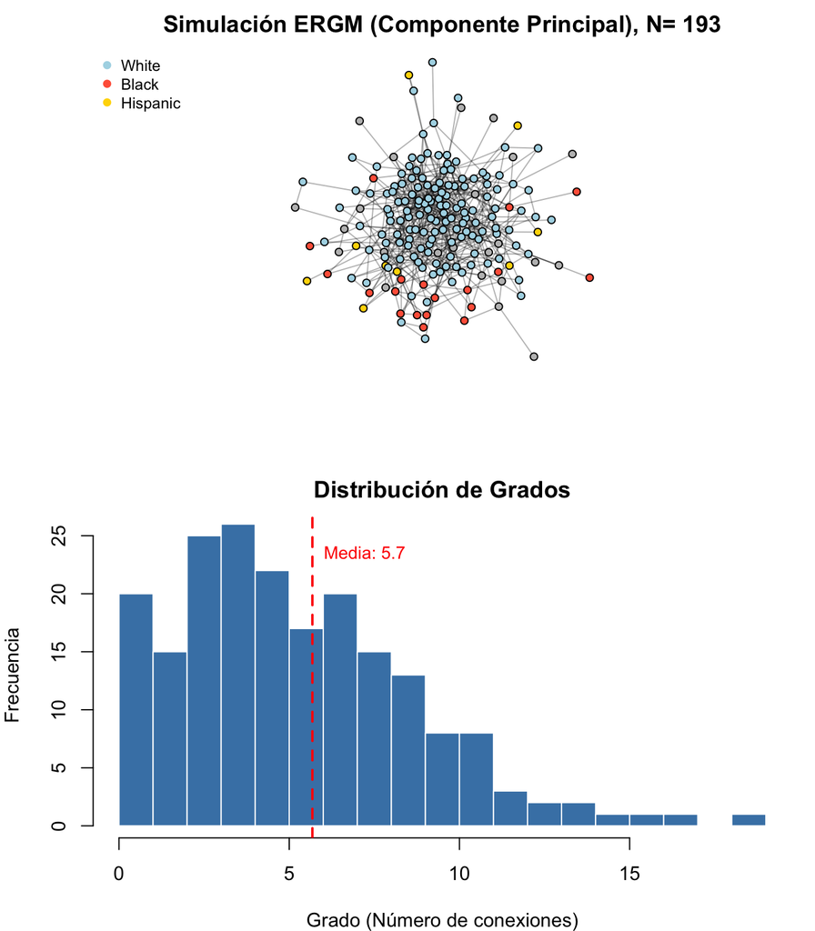

Red simulada (N=200): Componente Principal y Distribución de Grado

```r
library(igraph)
library(intergraph)

# 1. Convertir a igraph
g_sim <- asIgraph(final_net)

# 2. Extraer Componente Gigante
comps <- decompose(g_sim, mode = "weak")
g_main <- comps[[which.max(sapply(comps, vcount))]]

# Colores por Raza (en el componente)
V(g_main)$color <- case_when(
    V(g_main)$race == "1" ~ "lightblue", # White
    V(g_main)$race == "2" ~ "tomato", # Black
    V(g_main)$race == "3" ~ "gold", # Hispanic
    TRUE ~ "gray"
)

# Layout: Dividimos el espacio gráfico
par(mfrow = c(2, 1), mar = c(4, 4, 2, 1))

# --- Plot 1: Red (Giant Component) ---
plot(g_main,
    layout = layout_with_fr(g_main),
    vertex.size = 5,
    vertex.label = NA,
    edge.color = adjustcolor("black", alpha.f = 0.3),
    main = paste("Simulación ERGM (Componente Principal), N=", vcount(g_main))
)
legend("topleft",
    legend = c("White", "Black", "Hispanic"),
    col = c("lightblue", "tomato", "gold"), pch = 19, bty = "n", cex = 0.8
)

# --- Plot 2: Distribución de Grados ---
deg <- degree(g_sim)
mean_deg <- mean(deg)

hist(deg,
    breaks = 15, col = "steelblue", border = "white",
    main = "Distribución de Grados",
    xlab = "Grado (Número de conexiones)", ylab = "Frecuencia"
)
abline(v = mean_deg, col = "red", lwd = 2, lty = 2)
text(mean_deg, max(table(deg)) * 0.9,
    paste("Media:", round(mean_deg, 1)),
    pos = 4, col = "red", cex = 0.9
)
```